# CAR-T QSP — R ↔︎ Julia Full-Trajectory Cross-Validation

6-state LD-recovery model · rxode2 (lsoda) vs DifferentialEquations.jl (Rodas5P)

Published

June 7, 2026

## Overview

This report cross-validates the canonical 6-state CAR-T QSP model (LD-recovery structure; see `canonical_spec.md`) implemented independently in **rxode2** and **DifferentialEquations.jl**. Both stacks integrate identical equations on the same grid (0–365 d, step 0.5) with matched scalar tolerances (`rtol = atol = 1e-8`). A neutral **scipy** solve is included as an optional third anchor. Agreement is a transcription-equivalence check — it confirms the model is *encoded* identically in both ecosystems, not that the model is biologically correct.

Inputs (produced by the prior run steps, then `quarto render` this file):

- `r_traj.csv` — `Rscript cart_qsp_ld_rxode2.R`
- `julia_traj.csv` — `julia cart_qsp_ld.jl`
- `reference_traj.csv` — `python cart_qsp_ld_reference.py` *(optional)*

## Trajectory overlays

If the encodings agree, the thin Julia line sits inside the thick rxode2 line, and scipy (dotted) overlays both. Any visible separation flags a real divergence.

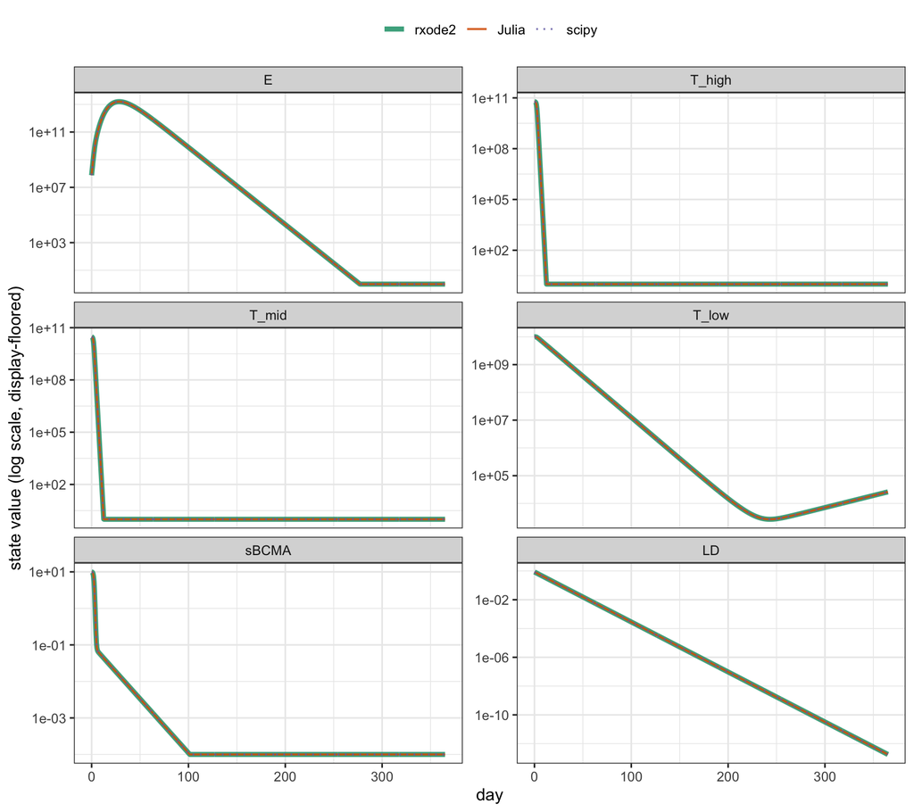

## Scaled-error traces (rxode2 vs Julia)

Where, and how large, any disagreement is over time. Dashed red is the acceptance threshold.

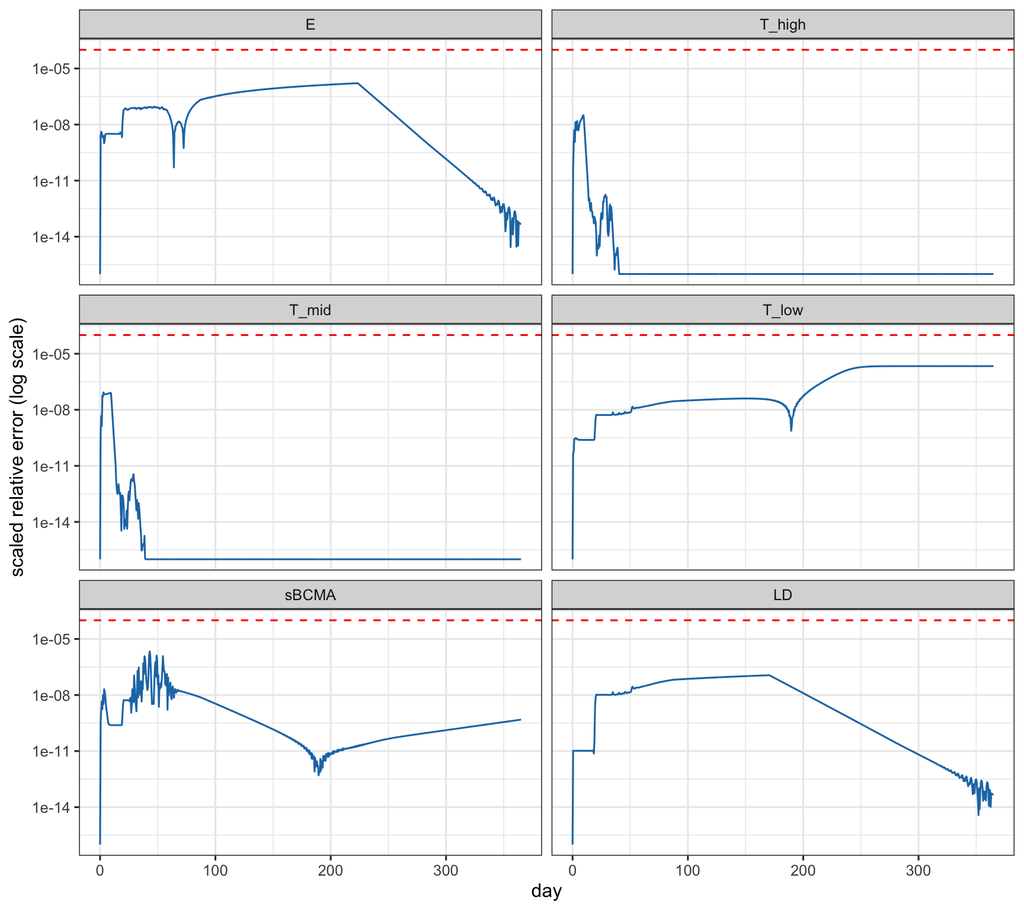

## Verdict

Per-state scaled error (acceptance <= 1e-04)

| state | max_scaled_err | at_day | rxode2 | Julia | pass |
| --- | --- | --- | --- | --- | --- |
| E | 1.6e-06 | 223.0 | 1.061e+03 | 1.061e+03 | PASS |
| T_high | 0.0e+00 | 9.5 | 1.294e+03 | 1.294e+03 | PASS |
| T_mid | 1.0e-07 | 3.0 | 2.443e+09 | 2.443e+09 | PASS |
| T_low | 2.2e-06 | 359.5 | 2.337e+04 | 2.337e+04 | PASS |
| sBCMA | 2.2e-06 | 43.0 | 5.399e-03 | 5.399e-03 | PASS |
| LD | 1.0e-07 | 170.0 | 1.100e-06 | 1.100e-06 | PASS |

**✅ PASS — encodings are equivalent.**  
Every state agrees within tolerance across the full 365-day trajectory; the rxode2 and Julia implementations are transcription-equivalent.

### Three-way agreement (vs scipy anchor)

| state | R_vs_scipy | Julia_vs_scipy |
| --- | --- | --- |
| E | 1.70e-06 | 1.00e-07 |
| T_high | 0.00e+00 | 0.00e+00 |
| T_mid | 0.00e+00 | 1.00e-07 |
| T_low | 2.20e-06 | 0.00e+00 |
| sBCMA | 1.75e-05 | 1.75e-05 |
| LD | 1.00e-07 | 0.00e+00 |